# Exploring Neurons Activity in the Mouse Brain

# 4 Descriptive Analysis

In order to build our prediction model, we will first explore the features of the data set. In particular, would like to first describe the data structure across all 18 sessions.

| Session | Mouse Name | Experiment Date | Number of Brain Area | Number of Neurons | Number of Trials | Success Rate |
| --- | --- | --- | --- | --- | --- | --- |
| 1 | Cori | 2016-12-14 | 8 | 734 | 114 | 0.61 |
| 2 | Cori | 2016-12-17 | 5 | 1070 | 251 | 0.63 |
| 3 | Cori | 2016-12-18 | 11 | 619 | 228 | 0.66 |
| 4 | Forssmann | 2017-11-01 | 11 | 1769 | 249 | 0.67 |
| 5 | Forssmann | 2017-11-02 | 10 | 1077 | 254 | 0.66 |
| 6 | Forssmann | 2017-11-04 | 5 | 1169 | 290 | 0.74 |
| 7 | Forssmann | 2017-11-05 | 8 | 584 | 252 | 0.67 |
| 8 | Hench | 2017-06-15 | 15 | 1157 | 250 | 0.64 |
| 9 | Hench | 2017-06-16 | 12 | 788 | 372 | 0.69 |
| 10 | Hench | 2017-06-17 | 13 | 1172 | 447 | 0.62 |
| 11 | Hench | 2017-06-18 | 6 | 857 | 342 | 0.80 |
| 12 | Lederberg | 2017-12-05 | 12 | 698 | 340 | 0.74 |
| 13 | Lederberg | 2017-12-06 | 15 | 983 | 300 | 0.80 |
| 14 | Lederberg | 2017-12-07 | 10 | 756 | 268 | 0.69 |
| 15 | Lederberg | 2017-12-08 | 8 | 743 | 404 | 0.76 |
| 16 | Lederberg | 2017-12-09 | 6 | 474 | 280 | 0.72 |
| 17 | Lederberg | 2017-12-10 | 6 | 565 | 224 | 0.83 |
| 18 | Lederberg | 2017-12-11 | 10 | 1090 | 216 | 0.81 |

**Table 1**. Data Structure Across Sessions.

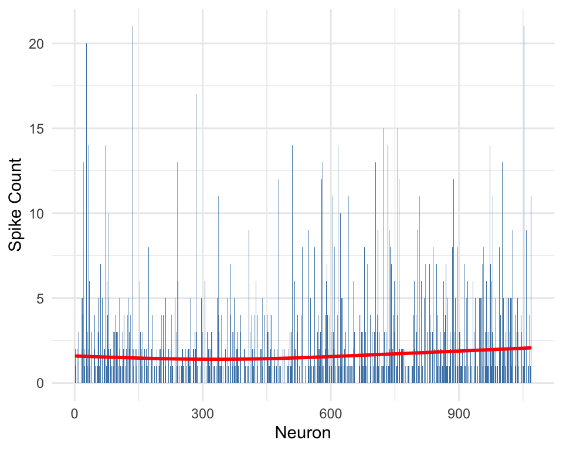

**Figure 1**. Total Spike for Each Neuron in Session 2 Trial 1 (Feedback: -1)

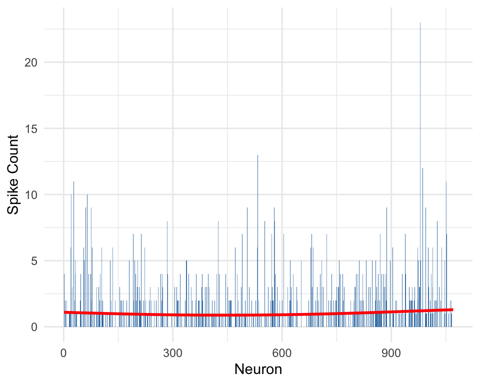

**Figure 2**. Total Spike for Each Neuron in Session 2 Trial 2 (Feedback: 1)

Looking at the total number of spikes for each neuron in a trial of a session based on the feedback type allows us to explore the neural activities during each trial and understand how they are influenced by different feedback types. By examining the spike count in **Figure 1** and **Figure 2**, we can see that, on average, neurons tend to exhibit a higher spike count in response to feedback -1 compared to feedback 1. This suggests that the neural population may respond more strongly to feedback -1 compared to feedback 1.

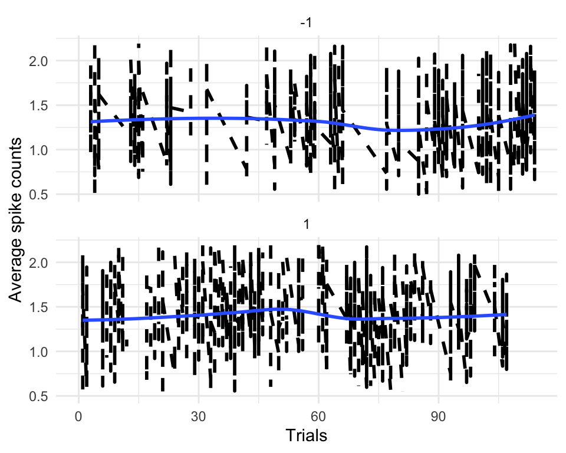

**Figure 3**. Spikes Per Neuron in Session 1 by Feedback Type

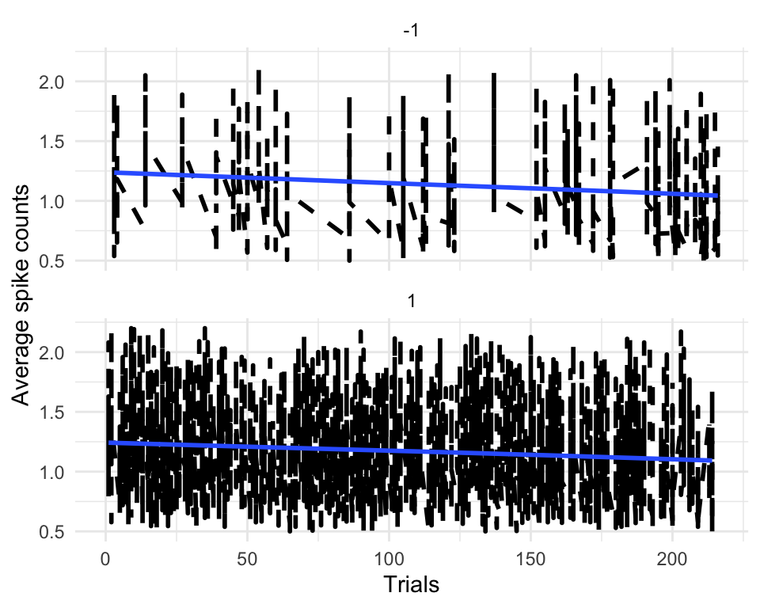

**Figure 4**. Spikes Per Neuron in Session 18 by Feedback Type

To provide further insights into potential differences in the underlying neural dynamics related to different feedback types, we will explore the changes across trials by looking at the average spike counts across all trials in a session. In **Figure 3** and **Figure 4**, we can see that the average spike counts across trials are almost the same for both feedback 1 and feedback -1. This means that, on average, there is no significant difference in the number of spikes recorded from neurons during trials associated with feedback 1 compared to trials associated with feedback -1. However, we can observe that there is more neural activity in feedback 1 than feedback -1 for Session 18, which could be related to the high success rate in that session.

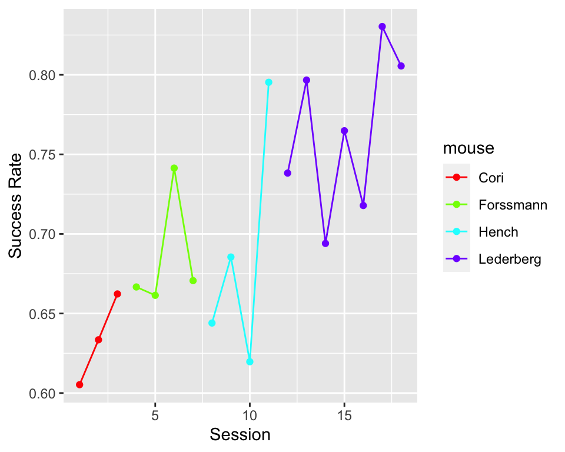

**Figure 5**. Success Rate Across Session and Mice

# 5 Data Integration

Using the findings from the Descriptive Analysis section, we propose an approach to combine data across trials in order to obtain a more comprehensive understanding of the research problem.

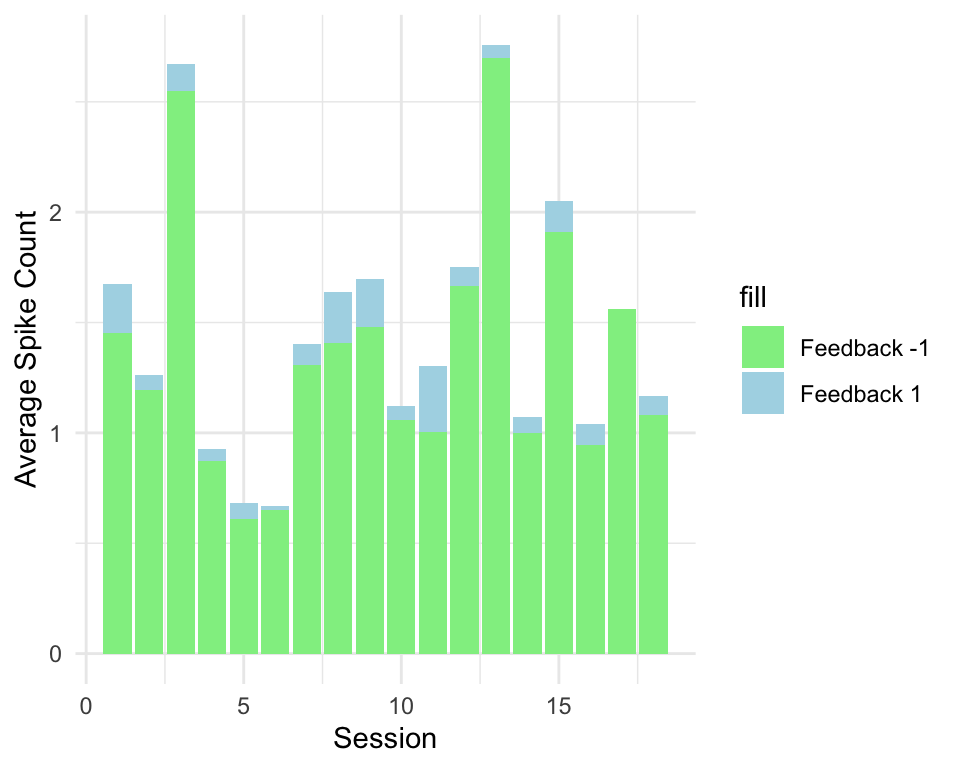

**Figure 6**. Average Spike Counts in Feedback 1 and Feedback -1

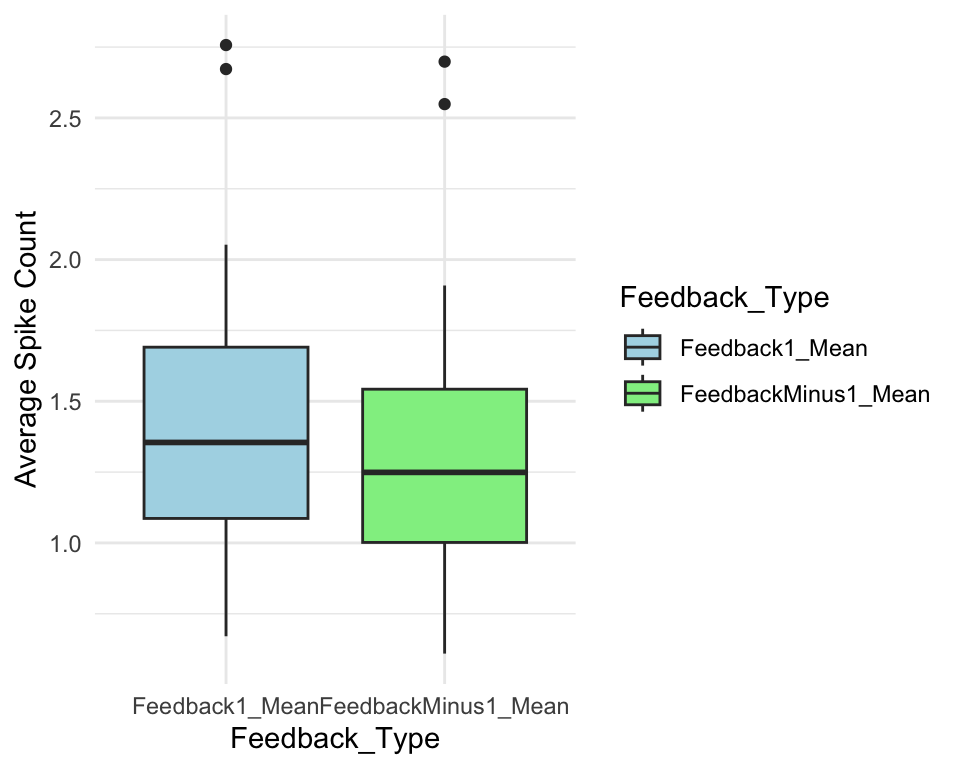

**Figure 7**. Average Spike Count Comparison

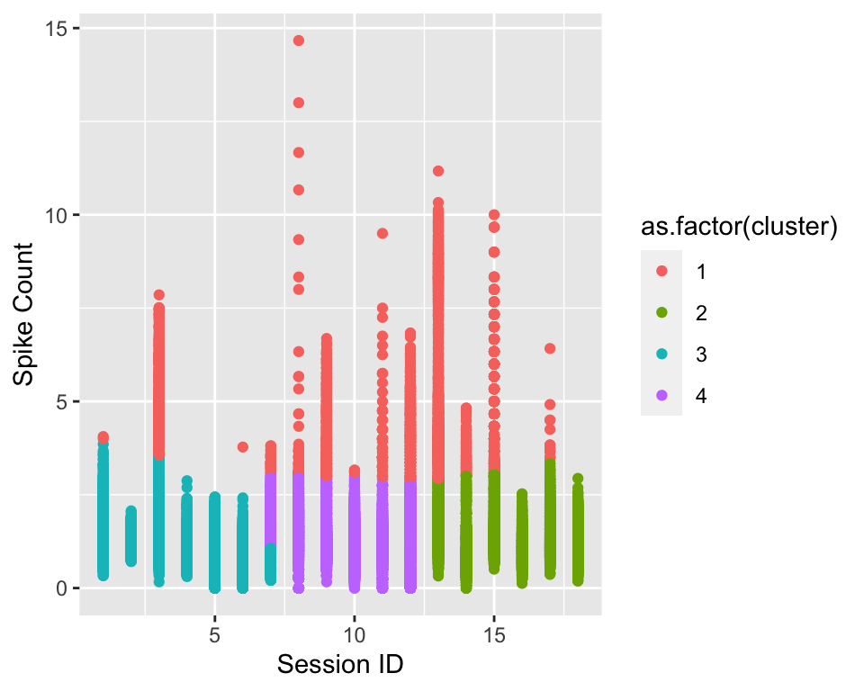

**Figure 8**. Clustering Results by Session (Feedback: 1)

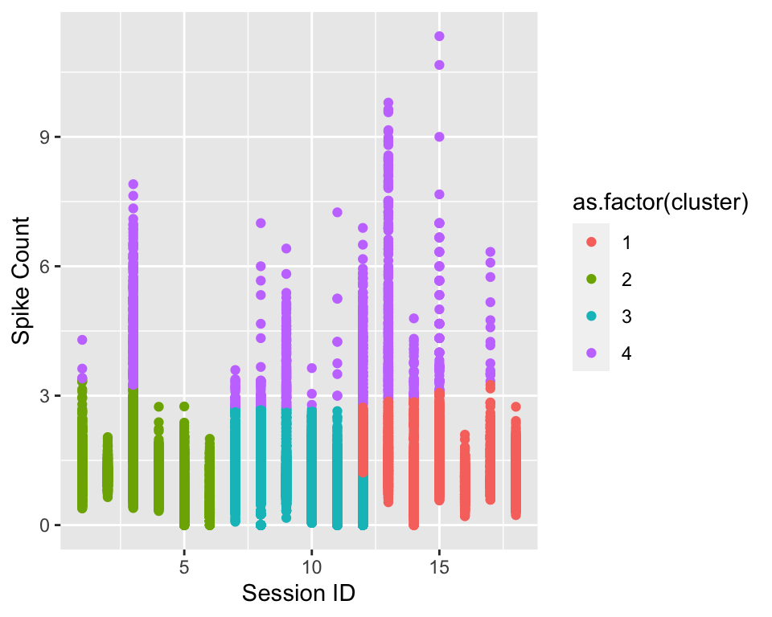

**Figure 9**. Clustering Results by Session (Feedback: -1)

# 6 Predictive Modeling

```
##       Predicted
## Actual -1  1
##     -1 21 24
##     1   3 66
```

```
## [1] "Misclassification rate:  0.2368"
```

```
## [1] "Accuracy rate:  0.7632"
```

For Session 1, the confusion matrix shows that the model correctly classified 21 trials of feedback type -1. It also correctly classified 66 trials of feedback type 1. The misclassification rate for this model is 0.2368 or 23.68%. This means the model incorrectly predicted the outcome for 23.68% of the feedback types. The opposite of the misclassification rate would be accuracy, which is 76.32%. This means the model correctly predicted the outcome for 76.32% of the feedback types.

```
##       Predicted
## Actual  -1   1
##     -1   0  42
##     1    0 174
```

```
## [1] "Misclassification rate:  0.1944"
```

```
## [1] "Accuracy rate:  0.8056"
```

# 7 Discussion

The analysis of neural activity in response to different feedback types showed that neurons generally exhibited a slightly higher spike count in response to feedback 1 compared to feedback -1 across multiple sessions. This suggests a potential relationship between feedback type and neural activity. The clustering results also supported this finding, as distinct groups of neurons showed similar response patterns for each feedback type.

Examining success rates across sessions and mice revealed variations in performance. Certain mice consistently had higher success rates, indicating differences in task performance capabilities among individuals. The high success rate in Session 18 corresponded with increased neural activity in response to feedback 1, suggesting a potential relationship between performance and neural response.

Combining data across trials provided a comprehensive understanding of the research problem, revealing no significant difference in neural activity between trials associated with feedback 1 and feedback -1. Clustering analysis further demonstrated distinct groups of neurons with consistent activity patterns for each feedback type, suggesting specific neural dynamics associated with different feedback types.

In summary, these findings provide insights into the relationship between neural activity and feedback types, variations in performance across sessions and mice, the benefits of combining trial data, the presence of distinct neural subgroups, and the predictive capabilities of the developed model. Together, they contribute to a deeper understanding of the neural mechanisms underlying behavioral responses to different feedback types in the context of the conducted experiments.

# 8 Reference

- Chen, Shizhe. STA 141A Course Project Consulting for Milestone I.
- Romo R, de Lafuente V. Conversion of sensory signals into perceptual decisions. Prog Neurobiol. 2013 Apr;103:41-75. doi: 10.1016/j.pneurobio.2012.03.007. Epub 2012 Mar 28. PMID: 22472964.
- Steinmetz NA, Zatka-Haas P, Carandini M, Harris KD. Distributed coding of choice, action and engagement across the mouse brain. Nature. 2019 Dec;576(7786):266-273. doi: 10.1038/s41586-019-1787-x. Epub 2019 Nov 27. PMID: 31776518; PMCID: PMC6913580.

## Appendix

```r
knitr::opts_chunk$set(fig.pos = 'H')
library(htmlwidgets)
library(tidyverse)
library(data.table)
library(dplyr)
session=list()
for(i in 1:18){
  session[[i]]=readRDS(paste('~/Downloads/UC Davis/Year 2/Quarter 3/STA 141A/sessions/session',i,'.rds',sep=''))
}

test=list()
for(i in 1:2){
  test[[i]]=readRDS(paste('~/Downloads/UC Davis/Year 2/Quarter 3/STA 141A/test/test',i,'.rds',sep=''))
}
## describe the data structures across sessions (e.g., number of neurons, number of trials, stimuli conditions, feedback types)

n_session = length(session)

# Create an empty tibble
meta <- tibble(
  session_num = rep(0, n_session),
  mouse_name = rep('name', n_session),
  date_exp = rep('date', n_session),
  n_brain_area = rep(0, n_session),
  n_neurons = rep(0, n_session),
  n_trials = rep(0, n_session),
  success_rate = rep(0, n_session)
)

for (i in 1:n_session) {
  tmp = session[[i]]; # temporary variable
  meta[i,1] = i
  meta[i,2] = tmp$mouse_name;
  meta[i,3] = tmp$date_exp;
  meta[i,4] = length(unique(tmp$brain_area));
  meta[i,5] = dim(tmp$spks[[1]])[1];
  meta[i,6] = length(tmp$feedback_type);
  meta[i,7] = mean(tmp$feedback_type+1)/2;
}

library(knitr)
library(kableExtra)

summary_tab <- kable(meta, format = "html", table.attr = "class='table table-striped'",digits=2, col.names = c("Session", "Mouse Name", "Experiment Date", "Number of Brain Area", "Number of Neurons", "Number of Trials", "Success Rate"))
summary_tab
library(dplyr)
library(tidyr)

calculate_trial_summary <- function(session, i.s) {
  average_spike_area <- function(i.t, session) {
    spk.trial <- session$spks[[i.t]]
    brain.area <- session$brain_area
    spk.count <- apply(spk.trial, 1, sum)
    spk.average <- tapply(spk.count, brain.area, mean)
    return(spk.average)
  }

  n.trial <- length(session[[i.s]]$feedback_type)
  n.area <- length(unique(session[[i.s]]$brain_area))

  # Create a data frame contain the average for counts for each area, feedback type, the two contrasts, and the trial id
  trial.summary <- matrix(nrow = n.trial, ncol = n.area + 4)

  for(i.t in 1:n.trial) {
    trial.summary[i.t,] <- c(average_spike_area(i.t, session[[i.s]]), session[[i.s]]$feedback_type[[i.t]], session[[i.s]]$contrast_left[[i.t]], session[[i.s]]$contrast_right[[i.t]], i.t)
  }
  colnames(trial.summary) <- c(names(average_spike_area(i.t, session[[i.s]])), 'feedback', 'left_contrast','right_contrast','id' )

  trial.summary <- as_tibble(trial.summary)

  # Convert to long format
  trial.summary_long <- trial.summary %>%
    pivot_longer(cols = -c(feedback, left_contrast, right_contrast, id), names_to = "Area", values_to = "spike_count")

  return(trial.summary_long)
}
i.s = 2 # session number
i.t = 1 # trial number
trial.summary <- calculate_trial_summary(session, i.s)
# A function that plot the neuron and spike count for a trial
library(ggplot2)
plot_spks <- function(session, session_index, trial_index) {
  # Get the spike count data and feedback type for the specified session and trial
  spks <- session[[session_index]]$spks[[trial_index]]
  feedback <- session[[session_index]]$feedback_type[[trial_index]]


  # Calculate the total spike count for each neuron
  total_spks <- apply(spks, 1, sum)

  # Calculate the average number of spikes per neuron
  # avg_spks <- mean(total_spks)

  # Create a data frame for visualization
  df <- data.frame(Neuron = 1:length(total_spks), Spike_Count = total_spks)

  # Create the bar plot
  ggplot(df, aes(x = Neuron, y = Spike_Count)) +
    geom_bar(stat = "identity", fill = "steelblue") +
    geom_smooth(se = FALSE, color = "red") +  # Add smoothed line without standard error
    xlim(0, length(total_spks)) +
    ylim(0, max(total_spks)) +
    xlab("Neuron") +
    ylab("Spike Count") +
    theme_minimal()
}


# Plot the graph
plot_spks(session, 2, 1)
plot_spks(session, 2, 2)
trial.summary.1 <- calculate_trial_summary(session, 1)
n.trial.1 = length(unique(trial.summary.1$id))

# Plot the avg spikes count across trial base on feedback type
ggplot(trial.summary.1, aes(x = id, y = spike_count)) +
  geom_line(lty = 2, lwd = 1) +
  geom_smooth(lwd = 1, se = FALSE) +
  xlim(0, n.trial.1) +
  ylim(0.5, 2.2) +
  xlab("Trials") +
  ylab("Average spike counts") +
  facet_wrap(~ feedback, ncol = 1) +
  theme_minimal()
trial.summary.18 <- calculate_trial_summary(session, 18)
n.trial.18 = length(unique(trial.summary.18$id))

# Plot the avg spikes count across trial base on feedback type
ggplot(trial.summary.18, aes(x = id, y = spike_count)) +
  geom_line(lty = 2, lwd = 1) +
  geom_smooth(lwd = 1, se = FALSE) +
  xlim(0, n.trial.18) +
  ylim(0.5, 2.2) +
  xlab("Trials") +
  ylab("Average spike counts") +
  facet_wrap(~ feedback, ncol = 1) +
  theme_minimal()
# Create an empty list to store trial summaries
trial_summaries <- vector("list", n_session)

# Iterate over the sessions and calculate the trial summary for each session
for (i in 1:n_session) {
  trial_summary<- calculate_trial_summary(session, i)

  # Add session ID to trial summary
  trial_summary$session_id <- i

  # Add mice name to trial summary
  trial_summary$mice <- meta$mouse_name[i]

  # Store trial summary in the list
  trial_summaries[[i]] <- trial_summary
}

# Combine trial summaries from all sessions into a single data frame
combined_summary <- do.call(rbind, trial_summaries)
# Success rate across sessions
new.meta <- tibble(session = 1:n_session,
                   success_rate = rep(0, n_session),
                   mouse = rep('name', n_session))

for(i in 1: n_session) {
  tmp <- session[[i]]
  new.meta[i,2] <- mean(tmp$feedback_type + 1) / 2
  new.meta[i,3] <- tmp$mouse
}

# Generate a unique set of colors for each mouse
mouse_colors <- rainbow(length(unique(meta$mouse_name)))

# Plot the line graph with colors based on mouse_name
ggplot(new.meta, aes(x = session, y = success_rate, group = mouse, color = mouse)) +
  geom_line() +
  geom_point() +
  labs(x = "Session", y = "Success Rate") +
  scale_color_manual(values = mouse_colors)
# Initialize the session_patterns list before the loop
session_patterns <- list()

for (i in 1:length(session)) {
  trial.summary <- calculate_trial_summary(session, i)

  # Filter the data for feedback types 1 and -1, then calculate the mean of spike_count
  feedback1_mean <- trial.summary %>%
    filter(feedback %in% 1) %>%
    summarise(mean_spike = mean(spike_count, na.rm = TRUE)) %>%
    pull(mean_spike)

  feedback_minus1_mean <- trial.summary %>%
    filter(feedback %in% -1) %>%
    summarise(mean_spike = mean(spike_count, na.rm = TRUE)) %>%
    pull(mean_spike)

  session_patterns[[i]] <- c(feedback1_mean, feedback_minus1_mean)
}
library(ggplot2)
# Convert the session_patterns list to a data frame for easier analysis
session_patterns_df <- as.data.frame(do.call(rbind, session_patterns))
session_patterns_df <- cbind(session_patterns_df, meta$session_num, meta$mouse_name)
colnames(session_patterns_df) <- c("Feedback1_Mean", "FeedbackMinus1_Mean", "Session", "Mice")

# Adjust bar width and add value labels
ggplot(session_patterns_df, aes(x = Session)) +
  geom_bar(aes(y = Feedback1_Mean, fill = "Feedback 1"), stat = "identity", position = "dodge") +
  geom_bar(aes(y = FeedbackMinus1_Mean, fill = "Feedback -1"), stat = "identity", position = "dodge") +
  scale_fill_manual(values = c("Feedback 1" = "lightblue", "Feedback -1" = "lightgreen")) +
  xlab("Session") +
  ylab("Average Spike Count") +
  theme_minimal()
# Analyze and visualize the patterns across sessions
# Boxplot comparing the average spike count between feedback 1 and feedback -1 across sessions

# Reshape the data from wide to long format
session_patterns_long <- gather(session_patterns_df, Feedback_Type, Average_Spike_Count, Feedback1_Mean:FeedbackMinus1_Mean)

# Plot the boxplot
ggplot(session_patterns_long, aes(x = Feedback_Type, y = Average_Spike_Count, fill = Feedback_Type)) +
  geom_boxplot() +
  labs(y = "Average Spike Count") +
  scale_fill_manual(values = c("lightblue", "lightgreen")) +
  theme_minimal()
## Clustering for feedback = 1

# Subset the data to only include feedback and spike_count
data <- combined_summary[, c("session_id", "spike_count","feedback")]

# Filter base on feedback type = 1
feedback1_data <- data %>% filter(feedback == 1)

# Scale the data
scaled_data <- scale(feedback1_data[, -3])

# Perform k-means clustering
k <- 4  # Number of clusters
kmeans_result <- kmeans(scaled_data, centers = k)

# Get cluster assignments
cluster_assignments <- kmeans_result$cluster

# Visualize the clusters
library(ggplot2)

feedback1_data %>%
  mutate(cluster = kmeans_result$cluster) %>%
  ggplot(aes(x = session_id, y = spike_count, color = as.factor(cluster))) +
  geom_point() +
  xlab("Session ID") +
  ylab("Spike Count")
### Clustering for feedback = -1
# Subset the data to only include feedback and spike_count
data <- combined_summary[, c("session_id", "spike_count","feedback")]

# Filter base on feedback type = 1
feedback1_data <- data %>% filter(feedback == -1)

# Scale the data
scaled_data <- scale(feedback1_data[, -3])

# Perform k-means clustering
k <- 4 # Number of clusters
kmeans_result <- kmeans(scaled_data, centers = k)

# Get cluster assignments
cluster_assignments <- kmeans_result$cluster

# Visualize the clusters
library(ggplot2)

feedback1_data %>%
  mutate(cluster = kmeans_result$cluster) %>%
  ggplot(aes(x = session_id, y = spike_count, color = as.factor(cluster))) +
  geom_point() +
  xlab("Session ID") +
  ylab("Spike Count")
# Create a data frame for a single session
createDataFrame <- function(session, i.s) {
  trial_data <- list()
  for (i in 1:length(session[[i.s]]$spks)) {
    spks_trial <- session[[i.s]]$spks[[i]]
    total_spikes <- sum(spks_trial)
    #avg_spikes <- mean(total_spikes)

    trial_data[[i]] <- data.frame(
    feedback = session[[i.s]]$feedback_type[[i]],
    left_contrast = session[[i.s]]$contrast_left[[i]],
    right_contrast = session[[i.s]]$contrast_right[[i]],
    #average_spikes = avg_spikes
    spike_count = total_spikes
    )
  }
  new_data <- do.call(rbind, trial_data)
  return(new_data)
}
# Prediction Model for Session 1

# Step 1: Prepare the data
session_1 <- createDataFrame(session, 1)
session_1_test <- createDataFrame(test, 1)

# Step 2: Split the data into training and test sets
test_data <- session_1
train_data <- session_1_test

# Step 3: Use the LDA model
library(MASS)
lda_model <- lda(feedback ~ left_contrast + right_contrast + spike_count , data = train_data)

# Step 4: Compute the _confusion matrix_ for the test data, and the misclassification error rate.
test_predict <- predict(lda_model, newdata = test_data)$class
confusion_matrix <- table(Actual = test_data$feedback, Predicted = test_predict)
mis_rate <- round(1 - sum(diag(confusion_matrix)) / sum(confusion_matrix), 4)
accuracy <- round(1 - mis_rate, 4)

confusion_matrix
paste("Misclassification rate: ", mis_rate)
paste("Accuracy rate: ", accuracy)
# Prediction Model for Session 18

# Step 1: Prepare the data
session_18 <- createDataFrame(session, 18)
session_18_test <- createDataFrame(test, 2)

# Step 2: Split the data into training and test sets
test_data <- session_18
train_data <- session_18_test

# Step 3: Use the LDA model
library(MASS)
lda_model <- lda(feedback ~ left_contrast + right_contrast + spike_count , data = train_data)

# Step 4: Compute the _confusion matrix_ for the test data, and the misclassification error rate.
test_predict <- predict(lda_model, newdata = test_data)$class
confusion_matrix <- table(Actual = test_data$feedback, Predicted = test_predict)
mis_rate <- round(1 - sum(diag(confusion_matrix)) / sum(confusion_matrix), 4)
accuracy <- round(1 - mis_rate, 4)

confusion_matrix
paste("Misclassification rate: ", mis_rate)
paste("Accuracy rate: ", accuracy)
sessionInfo()
```